# Homeless Dataset Regression Model 2 - Poisson Regression Model

#### Plot Philadelphia Boundary

```r
chicagoBoundary <- st_read("C:/Users/xiaot/Desktop/AdvancedGISTopic/phillymaps/boudary.shp")
```

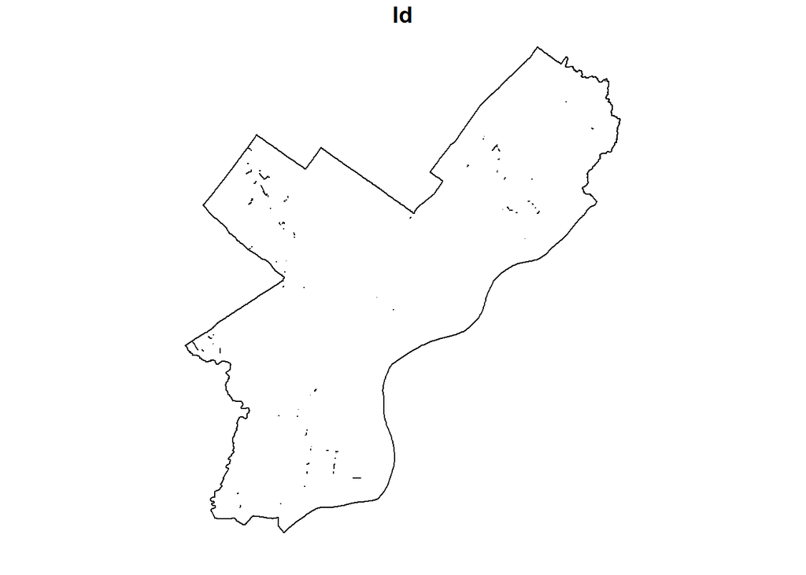

```r
plot(chicagoBoundary, col="#FFFFFF")
```

####Creating a Density Map of Shelters in Philadelphia

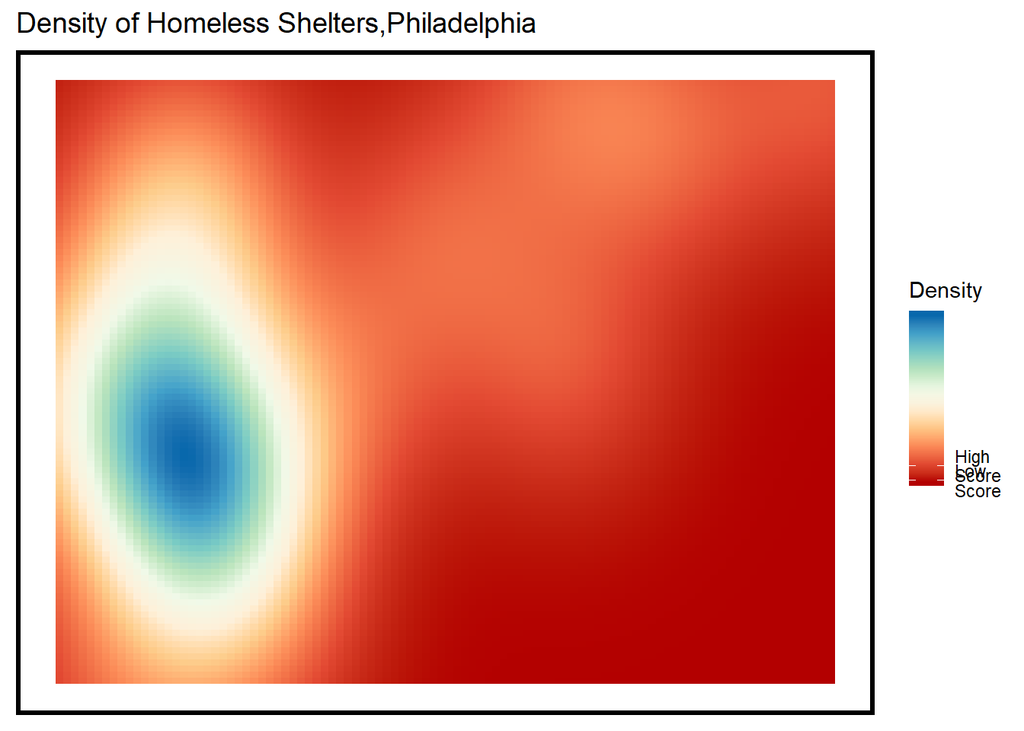

####Building a histogram We want to use the histogram to check the distribution of those homeless shelters - from the histogram we can see that the data is not normally distribued.

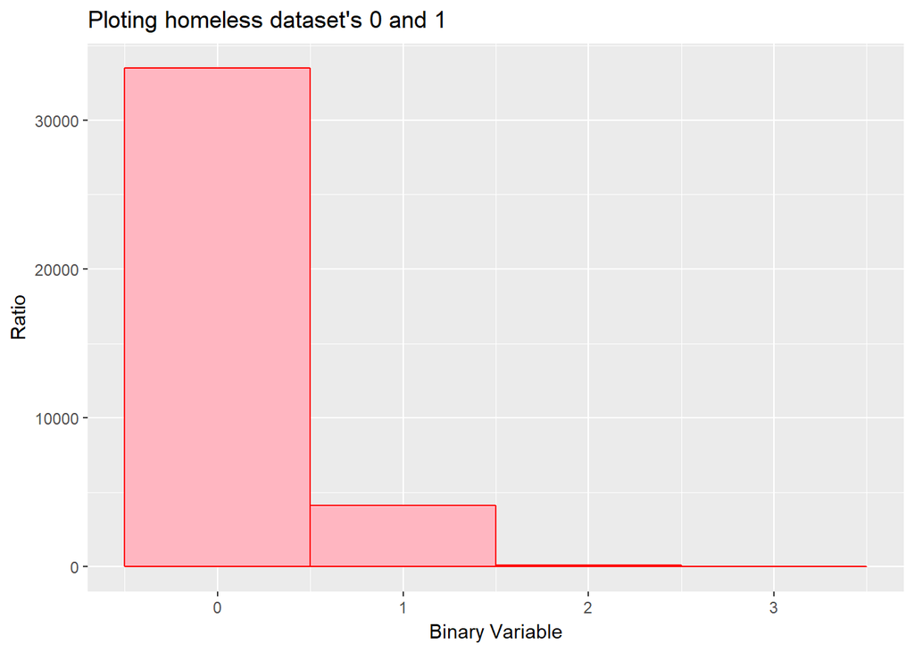

####Applying the Log Function Since the distribution of data is not normal distributed - there are much more 0s than 1s. We want to apply the log. However, there are still a large difference existing between 0 and 1, so the log function is not working well in the homeless dataset.

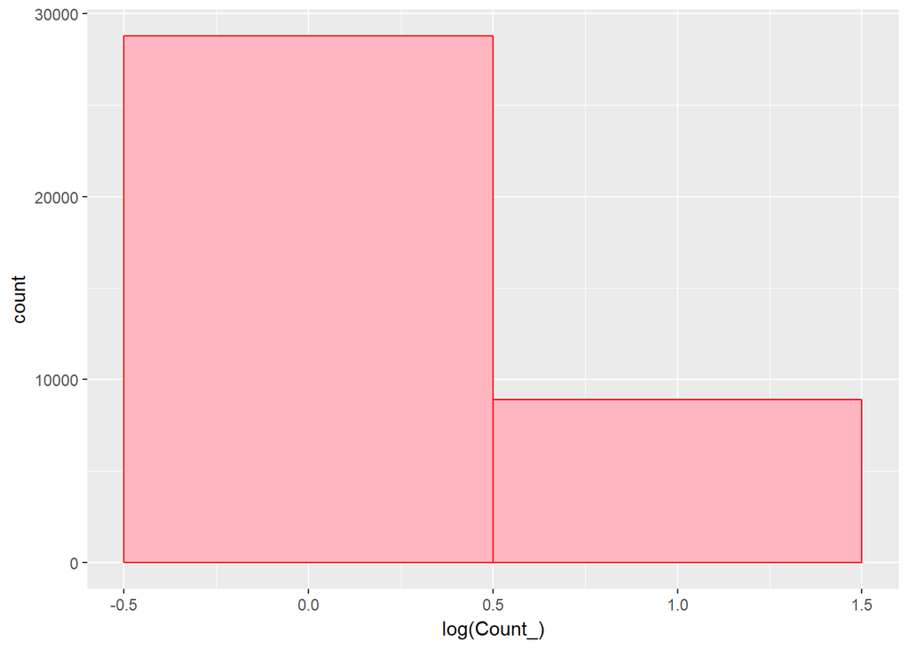